# Lab 3 — dimensionality reduction

```python
import json
import matplotlib.pyplot as plt
import numpy as np

from operator import itemgetter

%matplotlib inline
plt.style.use("ggplot")
```

```python
tags = sc.textFile("/ix/ml-20m/genome-tags.txt").map(json.loads)
```

```python
scores = sc.textFile("/ix/ml-20m/genome-scores.txt").map(json.loads)
```

## Exercise 3.1

```python
# M is the number of tags
M = tags.map(itemgetter("tag")).count()

# N is the number of movies with tags
N = scores.map(itemgetter("movieId")).distinct().count()
```

```python
print(M)
print(N)
```

```
1128
10381
```

```python
first_movie_id = scores.map(itemgetter("movieId")).take(1)[0]
```

```python
# index_to_id maps the movie index in the data matrix to it's id
index_to_id = {0: first_movie_id}

# method used to create the data matrix
def set_matrix(T,x,current_movie_index):
    #The tag id is the row index (vertical axis)
    tag_id = x[0]
    #The movie id is not the column index (horizontal axis) because not all movies are in scores
    movie_id = x[1]
    value = x[2]
    incr_index = False
    if index_to_id.get(current_movie_index) != movie_id:
        current_movie_index += 1
        index_to_id[current_movie_index] = movie_id
        incr_index = True
    T[x[0]-1][current_movie_index] = value
    return incr_index
```

```python
# T is our MxN data matrix
T = np.zeros((M,N))

f = scores.map(itemgetter("tagId", "movieId", "relevance")).collect()
i = 0

for x in f:
    if set_matrix(T,x,i):
        i += 1
np.shape(T)
```

```
(1128, 10381)
```

```python
var_by_tag = np.var(T, axis=1)
```

```python
# First, mean centering of data matrix T
c_T = (T.T - np.mean(T,axis=1)).T
# Covariance matrix MxM
C = np.cov(c_T)

np.shape(C)
```

```
(1128, 1128)
```

```python
# Eigen values (and vectors)
eig_val, eig_vec = np.linalg.eigh(C)
```

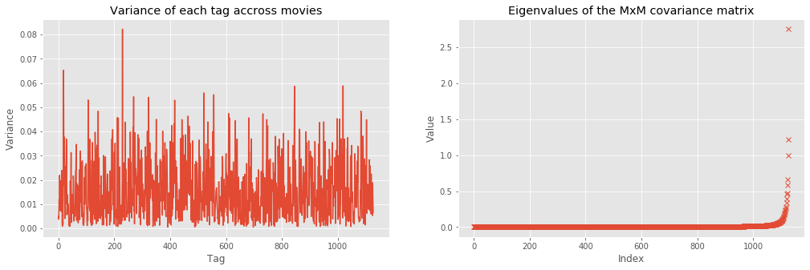

```python
fig, (ax1, ax2) = plt.subplots(ncols=2, figsize=(17,5))
ax1.plot(var_by_tag)
ax1.set(xlabel="Tag", ylabel="Variance")
ax1.set_title("Variance of each tag accross movies")
ax2.plot(eig_val, "x")
ax2.set(xlabel="Index", ylabel="Value")
ax2.set_title("Eigenvalues of the MxM covariance matrix")
fig.show()
```

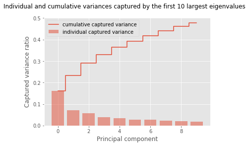

```python
total = sum(eig_val)
captured_variance = [(i / total) for i in sorted(eig_val, reverse=True)]
cumulated_variance = np.cumsum(captured_variance)

n = 10

v1 = captured_variance[0:n]
v2 = cumulated_variance[0:n]

plt.bar(range(0,n), v1, alpha=0.5, align='center', label='individual captured variance')
plt.step(range(0,n), v2, where='mid', label='cumulative captured variance')
plt.ylabel('Captured variance ratio')
plt.xlabel('Principal component')
plt.suptitle("Individual and cumulative variances captured by the first " + str(n) + " largest eigenvalues")
plt.legend(loc='best')
plt.show()
```

Note that in this graph, the eigenvalues have already been sorted in descending order.

```python
print(cumulated_variance[0])
print(cumulated_variance[35])
print(cumulated_variance[36])
```

```
0.16099840182365635
0.6665145090563254
0.6698488598691528
```

We can see there is a single value that's significantly larger than all of the others, and it captures more than 16% of the variability of the data.

We need the first 37 principal direction to capture more than 2/3 of the variability of the data

## Exercise 3.2 - Concept Space

```python
eig_pairs = []
for i in range(0,len(eig_val)):
    eig_pairs.append((eig_val[i], eig_vec[i]))
#sort by eigenvalue, descending order
eig_pairs.sort(key=lambda p: p[0], reverse=True)
```

```python
t = tags.map(itemgetter("tag")).collect()
```

```python
m = 5
best_10_tags = {}
worst_10_tags = {}
```

```python
for i in range(0,m):
    eigenvector_i = eig_pairs[i][1]
    sorted_args_a = np.argsort(eigenvector_i)
    sorted_args_d = np.flip(sorted_args_a)
    for j in range(0,10):
        worst_10_tags[(i,j)] = t[sorted_args_a[j]]
        best_10_tags[(i,j)] = t[sorted_args_d[j]]
```

```python
for i in range(0,m):
    print("dimension " + str(i+1) + ", 10 lowest coord tags:")
    for j in range(0,10):
        print(worst_10_tags[(i,j)])
    print("-------------------")
```

```
dimension 1, 10 lowest coord tags:
art
bad cgi
atheism
bad
survival
arms dealer
art house
small town
bullying
space travel
-------------------
dimension 2, 10 lowest coord tags:
astronauts
awful
based on a comic
awesome
author:alan moore
beatles
atmospheric
cinematography
berlin
baseball
-------------------
dimension 3, 10 lowest coord tags:
assassin
assassins
bad acting
bad science
author:neil gaiman
bad sequel
based on a tv show
assassination
whimsical
based on book
-------------------
dimension 4, 10 lowest coord tags:
colonialism
chess
depp & burton
cooking
ensemble cast
fun
complicated plot
computer animation
dark hero
bond
-------------------
dimension 5, 10 lowest coord tags:
dialogue driven
depp & burton
cold war
creepy
dark fantasy
comic
dark humor
chess
dolphins
death
-------------------
```

```python
for i in range(0,m):
    print("dimension " + str(i+1) + ", 10 highest coord tags:")
    for j in range(0,10):
        print(best_10_tags[(i,j)])
    print("-------------------")
```

```
dimension 1, 10 highest coord tags:
astronauts
based on a comic
awful
awesome
prohibition
samurai
berlin
cannibalism
beatles
author:alan moore
-------------------
dimension 2, 10 highest coord tags:
art
bad cgi
atheism
bad
australian
arms dealer
assassination
archaeology
art house
boring
-------------------
dimension 3, 10 highest coord tags:
bad cgi
bad
bad plot
australia
atheism
awesome
aviation
australian
weapons
artist
-------------------
dimension 4, 10 highest coord tags:
con men
coming of age
crude humor
divorce
computers
cute
cynical
confrontational
dialogue driven
erotic
-------------------
dimension 5, 10 highest coord tags:
cuba
dancing
dystopia
complicated plot
cult
cute!
divorce
clever
drug abuse
distopia
-------------------
```

Concepts to describe these dimensions:

- Dimension 1: fantastic movies based on comics
- Dimension 2: author and independent movies
- Dimension 3: bad movies
- Dimension 4: drama
- Dimension 5: dystopian dramas in cuba

Now, we create save to disk a dict that maps every tag name to it's coordinates in the 5 first principal components

```python
tag_to_coord = {}
for k in range(0,M):
    coords = []
    for l in range(0,m):
        coords.append(eig_pairs[l][1][k])
        tag_to_coord[t[k]] = coords
```

```python
file = open("tags_to_coord.json", "w")
json.dump(tag_to_coord, file)
file.close()
```

## Exercise 3.3 - Movie visualization

```python
import pickle
from bokeh.io import show, output_notebook
from bokeh.plotting import figure, ColumnDataSource
from bokeh.models import HoverTool, ResetTool, PanTool, WheelZoomTool, SaveTool
output_notebook()
```

```python
with open("selected-movies.pickle", "rb") as f:
    movies = pickle.load(f, encoding="utf-8")
```

```python
def get_key(val):
    for key, value in index_to_id.items():
         if val == value:
            return key
    return -1
```

```python
# define V matrix with the first 2 components
V = np.zeros((2,M))

for i in range(0,2):
    V[i] = eig_pairs[i][1]
V = V.T
```

```python
np.shape(V)
```

```
(1128, 2)
```

```python
# define X matrix with the selected movies and their tag values (Mxlen(movies))
l = len(movies)
X = np.zeros((l,M))
for i in range(0,l):
    ind = get_key(movies[i][0])
    vec = T[ : , ind]
    X[i] = vec
```

```python
# Y is the projection of movies on the first two principal directions
Y = X @ V
```

```python
np.shape(Y)
```

```
(37, 2)
```

```python
from matplotlib.colors import rgb2hex
cmap = plt.get_cmap('viridis')
def val2rgb(val):
    return rgb2hex(cmap(val)[:3])
```

```python
source = ColumnDataSource(
    data={
        "x": Y.T[0],
        "y": Y.T[1],
        "title": [x[1] for x in movies],
        "color": [val2rgb(x[2]) for x in movies],
        "score": [x[2] for x in movies]
    })

hover = HoverTool(
    tooltips=[
        ("Movie", "@title"),
        ("Score", "@score")
    ])
```

```python
tools = [hover, ResetTool(), PanTool(), WheelZoomTool(), SaveTool()]

p = figure(plot_width=960, plot_height=360, tools=tools, title="Movies projected on the first two principal directions, colored by score")
p.triangle("x", "y", source=source, size=20, color="color", alpha=0.5)
p.xaxis.axis_label = "direction 1"
p.yaxis.axis_label = "direction 2"
show(p, notebook_handle=True)
```

[interactive chart not shown]

`<Bokeh Notebook handle for In[43]>`

We see that *Superbad* is almost at position (0,0) because it doesn't fall in any of the two directions. It's a brillant comedy but neither independent nor based on comics/involving something supernatural.

*Take Care of My Cat* is placed at 0 on direction 1 but is high in the 2nd direction. This makes sens as it is an independent korean film that is pretty boring.

Based on the data we have, there doesn't seem to be any correlation between PCA directions and Rotten Tomatoes scores.